# Reproducible Research: Peer Assessment 1

G Turner

12/03/2017

### Loading and pre-processing the data

In order to complete the assignment, it is necessary to load and pre-process the data: Step (1.) read the data in to [R] Step (2.) amend date column to the [R] date format Step (3.) create a new df where NA’s are removed Step (4.) check the set up of the data tables

```r
library(readr)
activity.df <- read.csv("~/activity.csv", stringsAsFactors = FALSE)
activity.df$date <- as.Date(activity.df$date, format = "%Y-%m-%d")
activity.df_no_na <- activity.df[!is.na(activity.df$steps),]
## table with NA's
head(activity.df)
```

```
##   steps       date interval
## 1    NA 2012-10-01        0
## 2    NA 2012-10-01        5
## 3    NA 2012-10-01       10
## 4    NA 2012-10-01       15
## 5    NA 2012-10-01       20
## 6    NA 2012-10-01       25
```

```r
summary(activity.df)
```

```
##      steps             date               interval
##  Min.   :  0.00   Min.   :2012-10-01   Min.   :   0.0
##  1st Qu.:  0.00   1st Qu.:2012-10-16   1st Qu.: 588.8
##  Median :  0.00   Median :2012-10-31   Median :1177.5
##  Mean   : 37.38   Mean   :2012-10-31   Mean   :1177.5
##  3rd Qu.: 12.00   3rd Qu.:2012-11-15   3rd Qu.:1766.2
##  Max.   :806.00   Max.   :2012-11-30   Max.   :2355.0
##  NA's   :2304
```

```r
## table without NA's
head(activity.df_no_na)
```

```
##     steps       date interval
## 289     0 2012-10-02        0
## 290     0 2012-10-02        5
## 291     0 2012-10-02       10
## 292     0 2012-10-02       15
## 293     0 2012-10-02       20
## 294     0 2012-10-02       25
```

```r
summary(activity.df_no_na)
```

```
##      steps             date               interval
##  Min.   :  0.00   Min.   :2012-10-02   Min.   :   0.0
##  1st Qu.:  0.00   1st Qu.:2012-10-16   1st Qu.: 588.8
##  Median :  0.00   Median :2012-10-29   Median :1177.5
##  Mean   : 37.38   Mean   :2012-10-30   Mean   :1177.5
##  3rd Qu.: 12.00   3rd Qu.:2012-11-16   3rd Qu.:1766.2
##  Max.   :806.00   Max.   :2012-11-29   Max.   :2355.0
```

### What is mean total number of steps taken per day?

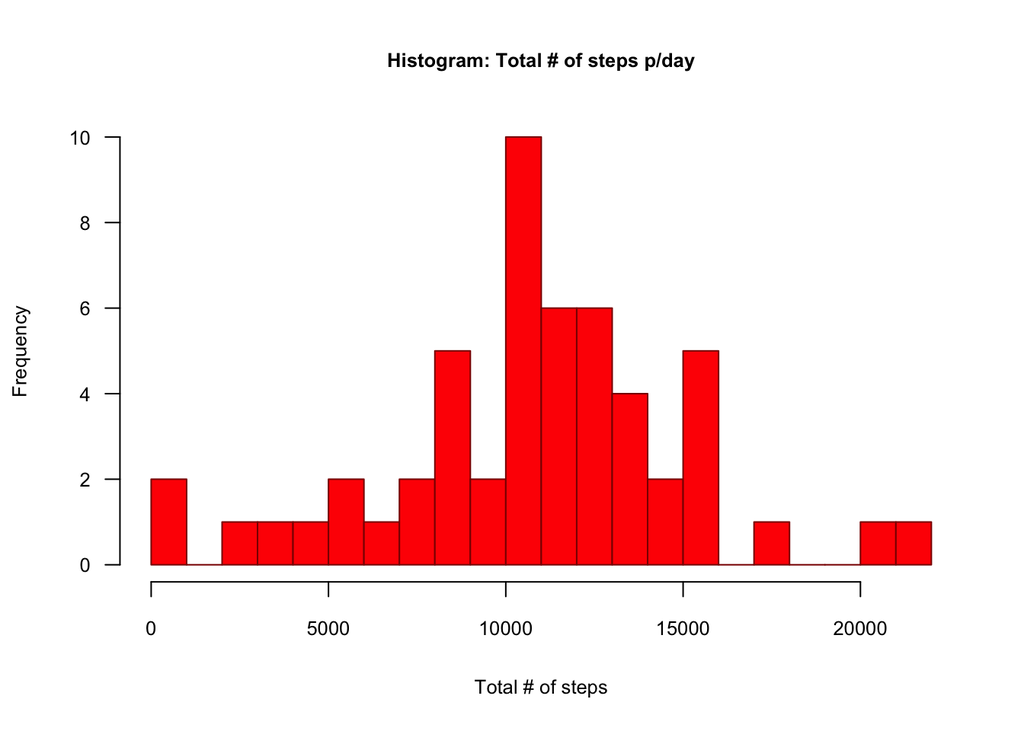

```r
library(ggplot2)
activity.df_sum <- aggregate(activity.df_no_na$steps, by = list(activity.df_no_na$date), FUN = sum)
names(activity.df_sum) <- c("Date", "Sum.Steps")
hist(activity.df_sum$Sum.Steps,
     xlab = "Total # of steps",
     main = "Histogram: Total # of steps p/day",
     cex.axis = .8,
     cex.lab = .8,
     cex.main = .8,
     breaks = 20,
     border = "dark red",
     col = "red",
     las = 1)
```

```r
## statistics of the new df
summary(activity.df_sum)
```

```
##       Date              Sum.Steps
##  Min.   :2012-10-02   Min.   :   41
##  1st Qu.:2012-10-16   1st Qu.: 8841
##  Median :2012-10-29   Median :10765
##  Mean   :2012-10-30   Mean   :10766
##  3rd Qu.:2012-11-16   3rd Qu.:13294
##  Max.   :2012-11-29   Max.   :21194
```

```r
options("scipen"=100, "digits"=4) # code ensures data is not shown in exponential notation, on the below in-line values.
mean0 <- mean(activity.df_sum$Sum.Steps)
median0 <- median(activity.df_sum$Sum.Steps)
```

Mean: 10766.1887 Median: 10765

## What is the average daily activity pattern?

To verify the avg daily activty pattern per 5 minutes intervals, we can run a line plot.

This code generates this step: a new data frame calculating the mean grouped by the variable interval, and plot this in a time plot:

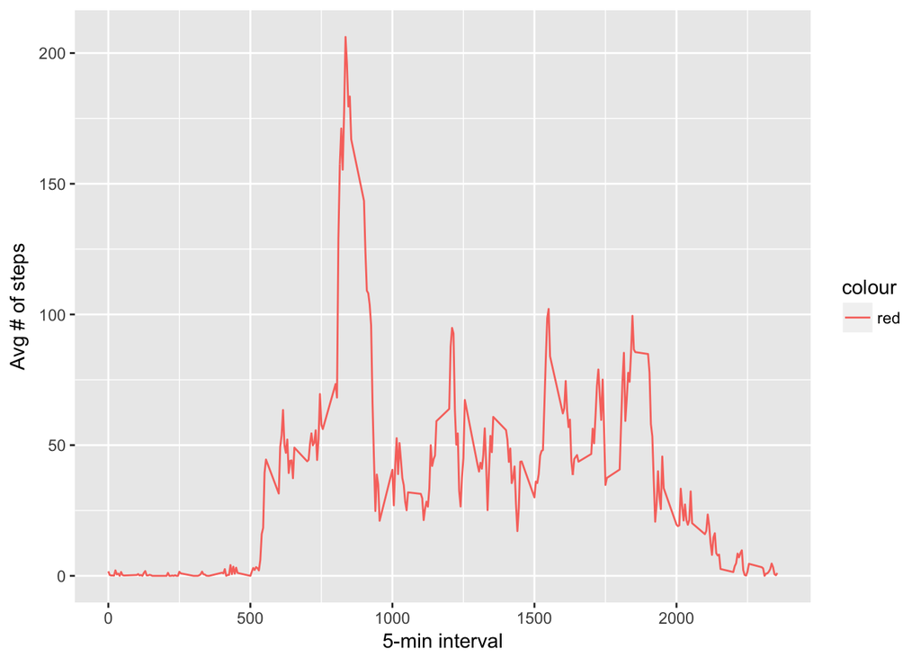

```r
library(ggplot2)
## calculate the mean grouped by the variable internal
activity.df_avg <- aggregate(x=list(steps=activity.df_no_na$steps), by=list(interval=activity.df_no_na$interval),
                      FUN=mean, na.rm=TRUE)
names(activity.df_avg) <- c("interval2", "Average.Steps")
## plot a time series
ggplot(data=activity.df_avg, aes(x=interval2, y=Average.Steps, col="red")) +
    geom_line() +
    xlab("5-min interval") +
    ylab("Avg # of steps")
```

```r
summary(activity.df_avg)
```

```
##    interval2    Average.Steps
##  Min.   :   0   Min.   :  0.00
##  1st Qu.: 589   1st Qu.:  2.49
##  Median :1178   Median : 34.11
##  Mean   :1178   Mean   : 37.38
##  3rd Qu.:1766   3rd Qu.: 52.83
##  Max.   :2355   Max.   :206.17
```

On average across all the days in the dataset, the 5-minute interval containing the maximum number of steps can be calculated via:

```r
data <- activity.df_avg[activity.df_avg$Average.Steps == max(activity.df_avg$Average.Steps),]
data
```

```
##     interval2 Average.Steps
## 104       835         206.2
```

The interval with the highest amount of steps is totaling steps of 206.1698.

## Input missing values

There are many days/intervals where there are missing values (coded as NA). The presence of missing days may introduce bias into some calculations or summaries of the data.

```r
## count the number of rows missing data
answer_cnt <- nrow(activity.df[is.na(activity.df$steps),])
## calculate the percentage of the data this represents
answer_pct <- paste(round(nrow(activity.df[is.na(activity.df$steps),])/nrow(activity.df) * 100,2), "%")
```

There are 2304 rows missing data. This represents 13.11 % of the data.

We can fill all of the missing values with the mean value for that 5-minute interval.

```r
## Replace each missing value with the mean value of its 5-minute interval
## checking the tables for compatability and field names
summary(activity.df)
```

```
##      steps            date               interval
##  Min.   :  0.0   Min.   :2012-10-01   Min.   :   0
##  1st Qu.:  0.0   1st Qu.:2012-10-16   1st Qu.: 589
##  Median :  0.0   Median :2012-10-31   Median :1178
##  Mean   : 37.4   Mean   :2012-10-31   Mean   :1178
##  3rd Qu.: 12.0   3rd Qu.:2012-11-15   3rd Qu.:1766
##  Max.   :806.0   Max.   :2012-11-30   Max.   :2355
##  NA's   :2304
```

```r
summary(activity.df_avg)
```

```
##    interval2    Average.Steps
##  Min.   :   0   Min.   :  0.00
##  1st Qu.: 589   1st Qu.:  2.49
##  Median :1178   Median : 34.11
##  Mean   :1178   Mean   : 37.38
##  3rd Qu.:1766   3rd Qu.: 52.83
##  Max.   :2355   Max.   :206.17
```

```r
## Run a merge
activity.df_fix2 <-  merge(activity.df, activity.df_avg, by.x = "interval", by.y = "interval2")
activity.df_fix2$steps.fix <- with(activity.df_fix2, ifelse(is.na(steps), Average.Steps, steps))
## Check output
summary(activity.df_fix2)
```

```
##     interval        steps            date            Average.Steps
##  Min.   :   0   Min.   :  0.0   Min.   :2012-10-01   Min.   :  0.00
##  1st Qu.: 589   1st Qu.:  0.0   1st Qu.:2012-10-16   1st Qu.:  2.49
##  Median :1178   Median :  0.0   Median :2012-10-31   Median : 34.11
##  Mean   :1178   Mean   : 37.4   Mean   :2012-10-31   Mean   : 37.38
##  3rd Qu.:1766   3rd Qu.: 12.0   3rd Qu.:2012-11-15   3rd Qu.: 52.83
##  Max.   :2355   Max.   :806.0   Max.   :2012-11-30   Max.   :206.17
##                 NA's   :2304
##    steps.fix
##  Min.   :  0.0
##  1st Qu.:  0.0
##  Median :  0.0
##  Mean   : 37.4
##  3rd Qu.: 27.0
##  Max.   :806.0
##
```

The new column steps.fix contains the count of steps after the correct for NA’s made. The next step will run a check on using this:

```r
activity.df_sum2 <- aggregate(activity.df_fix2$steps.fix, by = list(activity.df_fix2$date), FUN = sum)
names(activity.df_sum2) <- c("Date", "Sum.Steps")
summary(activity.df_sum2)
```

```
##       Date              Sum.Steps
##  Min.   :2012-10-01   Min.   :   41
##  1st Qu.:2012-10-16   1st Qu.: 9819
##  Median :2012-10-31   Median :10766
##  Mean   :2012-10-31   Mean   :10766
##  3rd Qu.:2012-11-15   3rd Qu.:12811
##  Max.   :2012-11-30   Max.   :21194
```

```r
mean2 <- mean(activity.df_sum2$Sum.Steps)
median2 <- median(activity.df_sum2$Sum.Steps)
```

Now, using the filled data set, let’s make a histogram of the total number of steps taken each day and calculate the mean and median total number of steps.

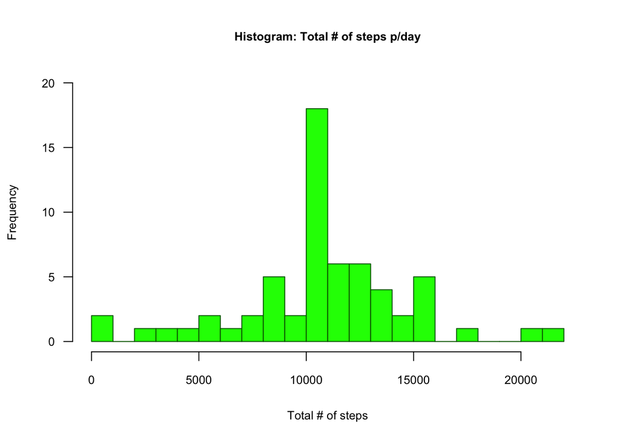

```r
hist(activity.df_sum2$Sum.Steps,
     xlab = "Total # of steps",
     main = "Histogram: Total # of steps p/day",
     cex.axis = .8,
     cex.lab = .8,
     cex.main = .8,
     breaks = 20,
     border = "dark green",
     col = "green",
     las = 1,
     ylim = c(0, 20))
```

First mean & median results: Mean: 10766.1887 Median: 10765 Second mean& median results: Mean: 10766.1887 Median: 10766.1887

## Are there differences in activity patterns between weekdays and weekends?

First, let’s find the day of the week for each measurement in the dataset. In this part, we use the dataset with the filled-in values.

```r
activity.df_fix2$weekday <- factor(with(activity.df_fix2, ifelse(weekdays(date) %in% c("Saturday", "Sunday"), "weekend", "weekdays")))
```

Then we calculate the mean per interval and weekday:

```r
summary(activity.df_fix2)
```

```
##     interval        steps            date            Average.Steps
##  Min.   :   0   Min.   :  0.0   Min.   :2012-10-01   Min.   :  0.00
##  1st Qu.: 589   1st Qu.:  0.0   1st Qu.:2012-10-16   1st Qu.:  2.49
##  Median :1178   Median :  0.0   Median :2012-10-31   Median : 34.11
##  Mean   :1178   Mean   : 37.4   Mean   :2012-10-31   Mean   : 37.38
##  3rd Qu.:1766   3rd Qu.: 12.0   3rd Qu.:2012-11-15   3rd Qu.: 52.83
##  Max.   :2355   Max.   :806.0   Max.   :2012-11-30   Max.   :206.17
##                 NA's   :2304
##    steps.fix         weekday
##  Min.   :  0.0   weekdays:12960
##  1st Qu.:  0.0   weekend : 4608
##  Median :  0.0
##  Mean   : 37.4
##  3rd Qu.: 27.0
##  Max.   :806.0
##
```

```r
activity.df_avg2 <- aggregate(steps.fix~interval+weekday, data = activity.df_fix2, FUN = mean)
names(activity.df_avg2) <- c("Interval", "Weekday", "Average.Steps")
```

Now, let’s make a panel plot containing plots of average number of steps taken on weekdays and weekends.

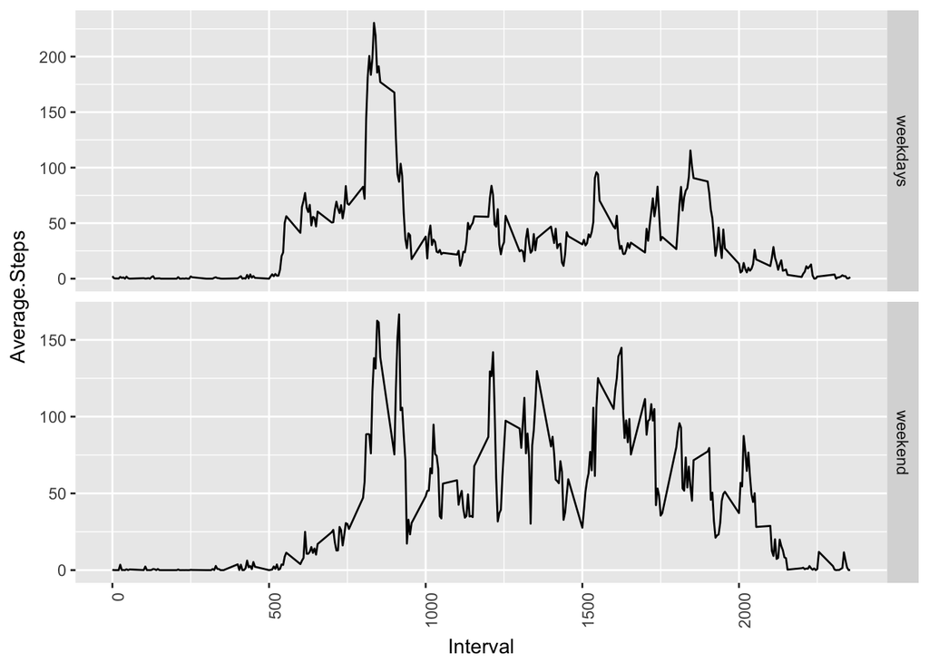

```r
timeplot <- ggplot(data=activity.df_avg2, aes(x=Interval, y=Average.Steps)) +
    theme(axis.text.x = element_text(angle = 90, hjust = 1)) +
    geom_line() +
    facet_grid(Weekday ~ ., scale ="free")
print(timeplot)
```

The results will show that weekday activity is concentrated at a particular interval/time - but activity at the weekend has more variability of the course of time.